# Census Progress

LD

8/6/2020

## Purpose

The goal is to look at how regions have progressed since the response rate plateau mid-May. While more affluent regions (such as Santa Clarita) started out with high response rates and continue to have high self-response rates, the harder-to-count regions (such as SELA, South LA, etc.) have consistently made the response rate gains week-to-week.

In this way we hope to show that the hard work of our partners has been the reason we have got so far with the count during a pandemic.

## Method

- I will pull in response rates from mid-May to the present. I don’t think I need a time series, just an overall net change since the plateau. I will pull in regional response rates as well as census tracts–we’ll see which looks better.
- I may want to aggregate to COVID neighborhood boundaries, we’ll see.

### 1. Load data

- Read in response rates as well as spatial data (regional boundaries, census tracts).

```r
## Load response rate data
filenames <- list.files(path = paste0(root, "convener_reports/standardized_data_archive/"), full.names=TRUE)

# get tract files for start and end of period
filenames <- filenames[filenames %like% "2020-05-22" | filenames %like% "2020-08-19"]


# load standardized report data
resp_list <- lapply(filenames, function(i){
  fread(i, data.table = FALSE, header=TRUE, stringsAsFactors = FALSE, encoding="Latin-1",
        colClasses = c("GEOID"="character"))
})

### Load CT level data with household counts (to aggregate to COVID polygongs)
filenames2 <- list.files(path = paste0(root, "self_response/"), full.names=TRUE)

# get tract files for start and end of period
filenames2 <- filenames2[(filenames2 %like% "2020-05-22" | filenames2 %like% "2020-08-19") & filenames2 %like% "selfresp_tract_converted_2020"]


# load standardized report data
resp_list_ct <- lapply(filenames2, function(i){
  fread(i, data.table = FALSE, header=TRUE, stringsAsFactors = FALSE, encoding="Latin-1",
        colClasses = c("GEOID10"="character"))
})



### Spatial Data ####

# load census tract boundaries
ct_sp <- st_read(paste0(root, "Carto/Tract_HTC_Regions_APCA.shp"), stringsAsFactors = FALSE)
# load spatial regional boundaries
reg_sp <- st_read(paste0(root, "Carto/regions_apca_prj3310.shp"), stringsAsFactors = FALSE)
```

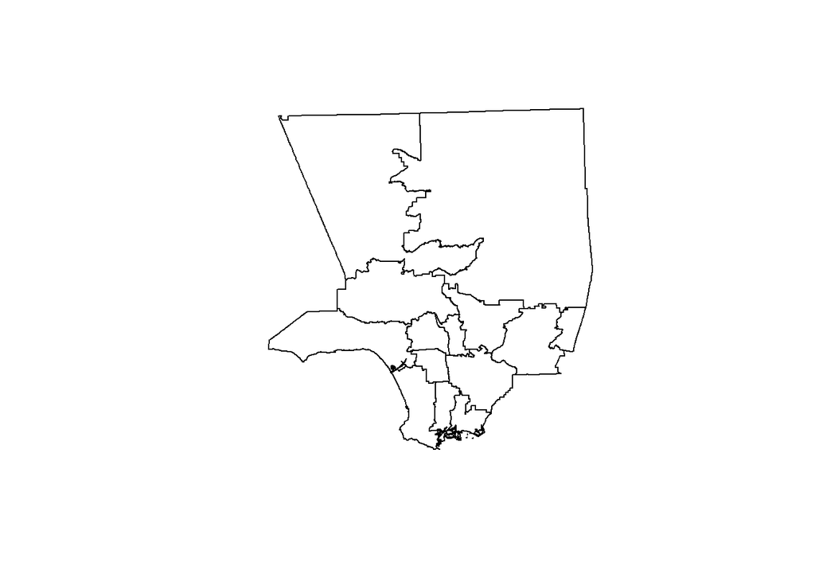

```r
# rename NELA
reg_sp$regname_ap[reg_sp$regname_ap=="Northeast/Eastside/East LA"] <- "Northeast-Eastside-East LA"

# review
plot(reg_sp$geometry)
```

### 2. Prepare response rate data

```r
# filter regional response rates
reg_list <- lapply(resp_list, function(x) x %>%
                     filter(level =="Region" & subject=="Response Rate" & value=="2020") %>%
                     select(region_name,  access_date, estimate))

regional_diff <- do.call("rbind", reg_list)

regional_diff <-
  regional_diff %>%
  pivot_wider(id_cols = region_name, names_from = access_date, values_from = estimate) %>%
   mutate(diff = `2020-08-19` - `2020-05-22` )

# review regional rr difference
head(regional_diff)
```

```
## # A tibble: 6 x 4
##   region_name                `2020-05-22` `2020-08-19`   diff
##   <chr>                             <dbl>        <dbl>  <dbl>
## 1 Antelope Valley                   0.542        0.586 0.0438
## 2 Central LA                        0.464        0.512 0.0481
## 3 Long Beach                        0.604        0.651 0.0474
## 4 Northeast-Eastside-East LA        0.492        0.553 0.0606
## 5 Pomona Valley                     0.626        0.676 0.0493
## 6 San Fernando Valley               0.585        0.634 0.0490
```

```r
# prepare tract response rates
ct_list <-  lapply(resp_list, function(x) x %>%
                     filter(level =="tract" & subject=="Response Rate" & value=="2020") %>%
                     select(label, GEOID, htc,  access_date, estimate))

ct_diff <- do.call("rbind", ct_list)

ct_diff <-
  ct_diff %>%
  pivot_wider(id_cols = c(label, GEOID, htc), names_from = access_date, values_from = estimate) %>%
   mutate(diff = `2020-08-19` - `2020-05-22` )

# review census tract rr difference
head(ct_diff)
```

```
## # A tibble: 6 x 6
##   label   GEOID         htc `2020-05-22` `2020-08-19`   diff
##   <chr>   <chr>       <int>        <dbl>        <dbl>  <dbl>
## 1 9001.02 06037900102    58        0.221        0.257 0.036
## 2 9001.03 06037900103    36        0.493        0.544 0.051
## 3 9001.04 06037900104    49        0.51         0.556 0.046
## 4 9002.01 06037900201    52        0.343        0.379 0.0363
## 5 9003    06037900300    38        0.496        0.532 0.0353
## 6 9005.01 06037900501    49        0.495        0.526 0.031
```

### 3. Map regional response rate progress

- Join regional response rate to boundaries and map.

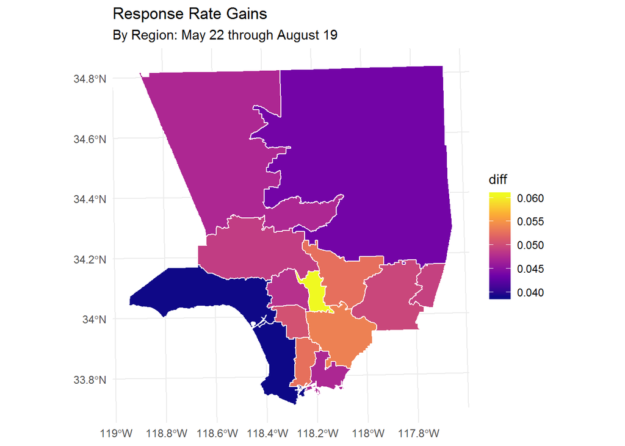

```r
regional_gain <-
  reg_sp %>%
  left_join(regional_diff, by=c("regname_ap"="region_name"))


ggplot(data = regional_gain) +
    geom_sf() +
    geom_sf(data = regional_gain, aes(fill = diff), color="white") +
    scale_fill_viridis_c(option = "plasma") +
  labs(title="Response Rate Gains",
       subtitle="By Region: May 22 through August 19")+
  theme_minimal()
```

```r
library(flextable)



flextable(regional_gain %>%
            as.data.frame() %>%
            select(regname_ap, diff) %>%
            mutate(
                   diff = round(diff*100,1),
                   ) %>%
            arrange(-diff)) %>%
  width(j = 1:2, width = 2.25) %>%
  set_header_labels(
    regname_ap ="Region",
    diff = "Self-Response Rate Difference 5/22 to 8/19") %>%
  flextable::font(fontname = "Franklin Gothic Book") %>%
  fontsize(size = 14, part = "header") %>%
  fontsize(size = 13, part = "body") %>%
  flextable::theme_alafoli()
```

| Region | Self-Response Rate Difference 5/22 to 8/19 |
| --- | --- |
| Northeast-Eastside-East LA | 6.1 |
| Southeast LA | 5.4 |
| San Gabriel Valley West | 5.3 |
| South Bay East | 5.3 |
| South LA | 5.1 |
| San Gabriel Valley East | 5.0 |
| Pomona Valley | 4.9 |
| San Fernando Valley | 4.9 |
| Central LA | 4.8 |
| Long Beach | 4.7 |
| Santa Clarita | 4.7 |
| Antelope Valley | 4.4 |
| West LA | 3.9 |
| South Bay West | 3.9 |

### 4. Map census tract response rate progress

- Join regional response rate to boundaries and map.

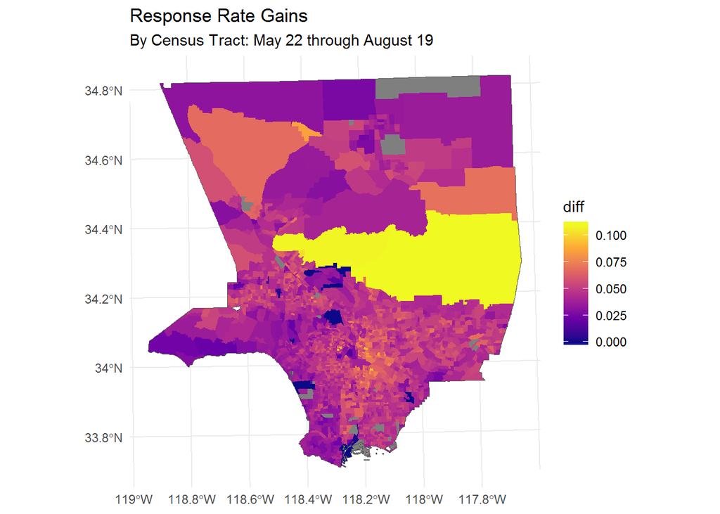

```r
ct_gain <-
  ct_sp %>%
  left_join(ct_diff, by=c("GEOID_1"="GEOID"))


ggplot(data = ct_gain) +
    geom_sf() +
    geom_sf(data = ct_gain, aes(fill = diff), color=NA) +
    scale_fill_viridis_c(option = "plasma") +
  labs(title="Response Rate Gains",
       subtitle="By Census Tract: May 22 through August 19")+
  theme_minimal()
```

## Map response rate progress to COVID polygons

More involved methodology–converting tracts to COVID polygons.

### 1. Load data

```r
library(RPostgreSQL)

# read in covid polygons from the db

#loads the PostgreSQL driver
drv <- dbDriver("PostgreSQL")

# create connection
con <- dbConnect(drv, dbname = "covid19_race_class",
                 host = "aws-postgres-db.c5udgz7ro8hq.us-west-2.rds.amazonaws.com", port = 5432,
                 user = "postgres", password = "password")

covid_sp <- st_read(con, query = "SELECT DISTINCT ON (lacounty_covid_case_rate_place_data.lac_place_name) lacounty_covid_case_rate_place_data.lac_place_name,
    lacounty_covid_case_rate_place_data.date,
    lacounty_covid_case_rate_place_data.confirmed_cases,
    lacounty_covid_case_rate_place_data.cases_per100k,
    lacounty_covid_case_rate_place_data.total_population,
    lacounty_covid_case_rate_place_data.geom
   FROM lacounty_covid_case_rate_place_data
  WHERE lacounty_covid_case_rate_place_data.lac_place_name IS NOT NULL
  ORDER BY lacounty_covid_case_rate_place_data.lac_place_name, lacounty_covid_case_rate_place_data.date DESC")


# read in crosswalk
xwalk <- fread(paste0(covidroot, "lac_place_tract_xwalk.csv"), stringsAsFactors = FALSE, data.table = FALSE,
               colClasses = c("GEOID"="character", "NAME"="character"))

head(xwalk)
```

```
##    lac_place_name       GEOID    NAME  area_int area_tract area_neighb
## 1 Adams-Normandie 06037221401 2214.01  3.517336   539518.9    960786.9
## 2 Adams-Normandie 06037221500    2215  7.957486   380671.1    960786.9
## 3 Adams-Normandie 06037221601 2216.01 16.863200   369828.0    960786.9
## 4 Adams-Normandie 06037221810 2218.10 12.912299   304339.4    960786.9
## 5 Adams-Normandie 06037221900    2219  9.588624   411416.5    960786.9
## 6 Adams-Normandie 06037222001 2220.01  2.012376   474263.2    960786.9
##        prc_int
## 1 6.519394e-06
## 2 2.090383e-05
## 3 4.559742e-05
## 4 4.242730e-05
## 5 2.330637e-05
## 6 4.243163e-06
```

### 2 Summarize by Neighborhood

- Use the COVID-Census crosswalk to map response rate gains by COVID polygon.
- Multiply the percent intersect by:
  - the number of households that responded
  - the total number of households
- Group by neighborhood name
- Sum proportional number of responding households, total number of households
  - divide to get the response rate by neighborhood

```r
# get tract response rates
covidpoly_sum <- lapply(resp_list_ct, function(x) x %>%

                       # filter only LA tracts
                       filter(GEOID10 %like% "06037") %>%
                       select(GEOID10, resp_house10, housecur, access_date) %>%

                       # join covid poly crosswalk
                       full_join(xwalk, by=c("GEOID10"="GEOID")) %>%

                       # proportional allocation to covid neighborhood
                       mutate(resp_hh_conv = resp_house10 * prc_int,
                              tot_hh_conv = housecur * prc_int) %>%

                       group_by(lac_place_name, access_date) %>%

                       #  calculate neighborhood response rate by dividng responding hh by total hh
                       summarize(resp_conv = sum(resp_hh_conv, na.rm = T),
                                 tothh_conv = sum(tot_hh_conv, na.rm = T),
                                 resp_prc = resp_conv/tothh_conv))


head(covidpoly_sum[[1]])
```

```
## # A tibble: 6 x 5
## # Groups:   lac_place_name [6]
##   lac_place_name          access_date resp_conv tothh_conv resp_prc
##   <chr>                   <chr>           <dbl>      <dbl>    <dbl>
## 1 Adams-Normandie         2020-05-22    1103.       2382.     0.463
## 2 Agoura Hills            2020-05-22    4950.       6795.     0.728
## 3 Alhambra                2020-05-22   19853.      29429.     0.675
## 4 Alsace                  2020-05-22    1581.       3416.     0.463
## 5 Angeles National Forest 2020-05-22       4.72       15.5    0.305
## 6 Angelino Heights        2020-05-22     399.        914.     0.436
```

```r
# collapse to df
covidpoly_sum_df <- do.call("rbind", covidpoly_sum)

# convert to wide df and calculate difference
covidpoly_sum_df <-
  covidpoly_sum_df %>%
  pivot_wider(id_cols = c(lac_place_name), names_from = access_date, values_from = c(resp_conv, tothh_conv, resp_prc)) %>%
   mutate(diff = `resp_prc_2020-08-19` - `resp_prc_2020-05-22`)

# review census tract rr difference
head(covidpoly_sum_df)
```

```
## # A tibble: 6 x 8
## # Groups:   lac_place_name [6]
##   lac_place_name `resp_conv_2020~ `resp_conv_2020~ `tothh_conv_202~
##   <chr>                     <dbl>            <dbl>            <dbl>
## 1 Adams-Normand~          1103.            1223.             2382.
## 2 Agoura Hills            4950.            5283.             6795.
## 3 Alhambra               19853.           21639.            29429.
## 4 Alsace                  1581.            1725.             3416.
## 5 Angeles Natio~             4.72             4.96             15.5
## 6 Angelino Heig~           399.             453.              914.
## # ... with 4 more variables: `tothh_conv_2020-08-19` <dbl>,
## #   `resp_prc_2020-05-22` <dbl>, `resp_prc_2020-08-19` <dbl>, diff <dbl>
```

### 3. Join response rate gains to COVID polygons

```r
# join to spatial covid polys
covidpoly_gain <-
  covid_sp %>%
  left_join(covidpoly_sum_df, by="lac_place_name")
```

Map:

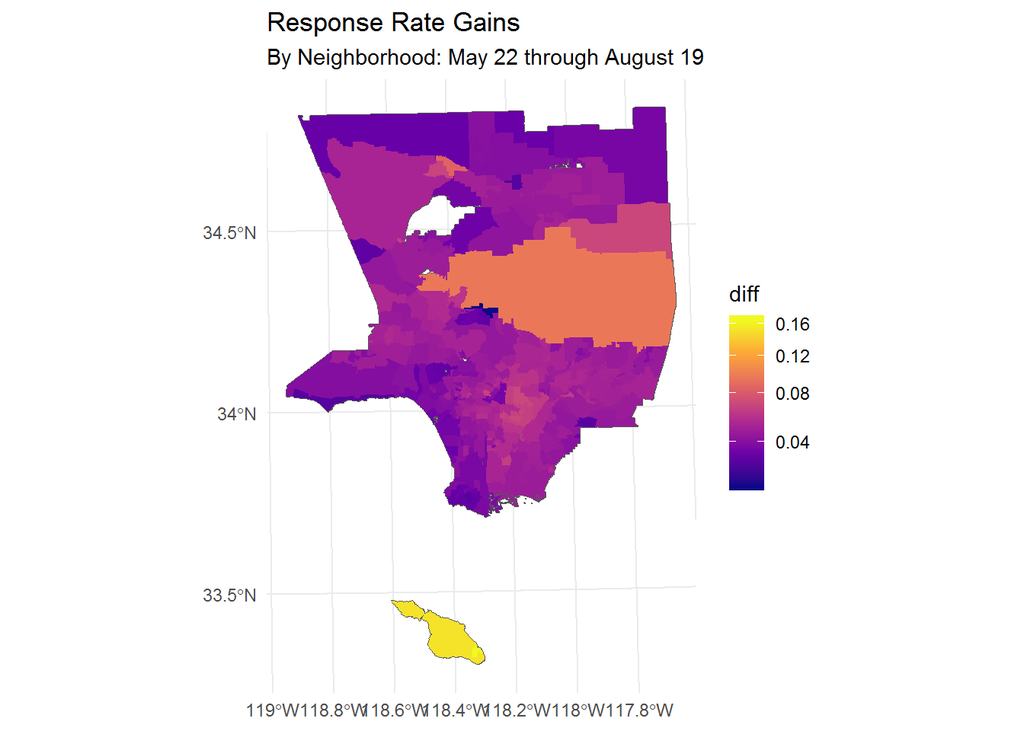

```r
ggplot(data = covidpoly_gain) +
    geom_sf() +
    geom_sf(data = covidpoly_gain, aes(fill = diff), color=NA) +
    scale_fill_viridis_c(option = "plasma",  trans = "sqrt") +
  labs(title="Response Rate Gains",
       subtitle="By Neighborhood: May 22 through August 19")+
  theme_minimal()
```

Export data

```r
# # export to geojson
# st_write(regional_gain, paste0(root, "LA Times/region_resp_0522_0819.geojson"), driver = "GeoJSON", delete_dsn = TRUE)
#
# st_write(ct_gain, paste0(root, "LA Times/censustract_resp_0522_0819.geojson"), driver = "GeoJSON", delete_dsn = TRUE)
#
# st_write(covidpoly_gain, paste0(root, "LA Times/covid_neighborhood_resp_0522_0819.geojson"), driver = "GeoJSON", delete_dsn = TRUE)


# # create connection
# con_census <- dbConnect(drv, dbname = "census_2020",
#                  host = "aws-postgres-db.c5udgz7ro8hq.us-west-2.rds.amazonaws.com", port = 5432,
#                  user = "postgres", password = "password")
#
#
# # Export to postgresql
# st_write(obj = covidpoly_gain, dsn = con_census, layer = "response_gains_neighborhood_0522_0805", delete_layer = TRUE, delete_dsn = TRUE)
#
#
#
# # write comment to table
# # add  data date to table name /comment
# sql_command <- "COMMENT ON TABLE response_gains_neighborhood_0522_0805 IS 'COVID-19 cases (as of 08/02/20) with Census 2020 response rates (from 5/22 and 8/19). Crosswalk census tracts to COVID neighborhoods using geographic proportional allocation and estimate census response rates for these neighborhoods. Response rate gains are the response rate increase from May 22 to Aug 19. COVID Race/Class neighborhood polygons are used so that response rates can be correlated with COVID rates.'"
#
# # send comment to database
# dbGetQuery(con_census, sql_command)
```

## Summary Stats

### COVID/HTC Typology

- The COVID/HTC Typology is determined by medians:
  - Communities with COVID-19 case rates higher than the median are considered “higher COVID” communities.
  - Communities with a mean HTC score (mean of HTC score of all census tracts in the community) higher than the median mean HTC score are considered “harder to count” communities.

```r
# load typology data to get mean HTC score from covid analysis
typology <- read.csv(paste0(covidroot, "covid_dem_resp.csv"), stringsAsFactors = FALSE)


# make covid/htc typology
covidpoly_gain <-
covidpoly_gain %>%
  left_join(typology %>%
              select(lac_place_name, mean_htc), by="lac_place_name") %>%

  mutate(htc_typ = ifelse(mean_htc > summary(typology$mean_htc)[3], "High HTC", "Low HTC"),
         covid_typ = ifelse(cases_per100k > summary(covidpoly_gain$cases_per100k)[3], "High COVID", "Low COVID"),
         typ = paste0(htc_typ, ", ", covid_typ))


table(covidpoly_gain$htc_typ, covidpoly_gain$covid_typ)
```

```
##
##            High COVID Low COVID
##   High HTC        111        40
##   Low HTC          40       111
```

### Correlation

#### COVID & Community HTC Mean

Look at correlation between COVID cases and community mean HTC score:

```r
# test correlation
#cor.test(covidpoly_gain$confirmed_cases, covidpoly_gain$mean_htc)
cor.test(covidpoly_gain$cases_per100k, covidpoly_gain$mean_htc)
```

```
##
##  Pearson's product-moment correlation
##
## data:  covidpoly_gain$cases_per100k and covidpoly_gain$mean_htc
## t = 12.443, df = 300, p-value < 2.2e-16
## alternative hypothesis: true correlation is not equal to 0
## 95 percent confidence interval:
##  0.5037663 0.6533009
## sample estimates:
##       cor
## 0.5834572
```

- COVID cases (per 100k) in communities is moderately positively correlated with mean HTC (correlation of 0.58).

#### COVID & Current Response Rate

```r
cor.test(covidpoly_gain$cases_per100k, covidpoly_gain$`resp_prc_2020-08-19`)
```

```
##
##  Pearson's product-moment correlation
##
## data:  covidpoly_gain$cases_per100k and covidpoly_gain$`resp_prc_2020-08-19`
## t = -3.6175, df = 300, p-value = 0.0003489
## alternative hypothesis: true correlation is not equal to 0
## 95 percent confidence interval:
##  -0.3101554 -0.0937460
## sample estimates:
##        cor
## -0.2044475
```

#### Community HTC Mean & Response Rate Gains

```r
cor.test(covidpoly_gain$mean_htc, covidpoly_gain$diff)
```

```
##
##  Pearson's product-moment correlation
##
## data:  covidpoly_gain$mean_htc and covidpoly_gain$diff
## t = 4.3001, df = 300, p-value = 2.312e-05
## alternative hypothesis: true correlation is not equal to 0
## 95 percent confidence interval:
##  0.1316680 0.3444494
## sample estimates:
##      cor
## 0.240952
```

- Community HTC mean is somewhat positively correlated with higher response rate gains (correlation of 0.24).